# 18_shear_2D

## 18_shear_2D

#### Question

1. A video-game developer is hoping to apply a vertical [shear](https://en.wikipedia.org/wiki/Shear_mapping) to a set of points by using matrix multiplication.

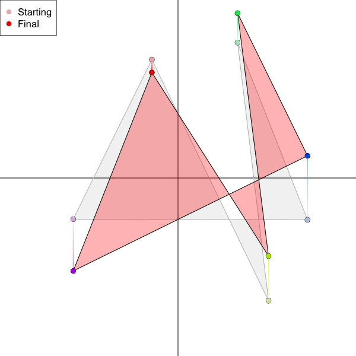

   The starting points are stored as rows in a 5 $\times$ 2 matrix $S$.

   $$S=\begin{bmatrix}
   -1.04 & 4.714\\
   3.603 & -4.886\\
   2.371 & 5.39\\
   5.156 & -1.663\\
   -4.171 & -1.64
   \end{bmatrix}$$

   The vertical shear matrix can be found by using $k=0.494$ in the formula matrix.

   $$T~=~\begin{bmatrix}
   1 & k\\
   0 & 1
   \end{bmatrix}$$

   The final points (in matrix $F$) are found by multiplying $S\cdot T$.

   $$F=S\cdot T$$

   That multiplication can be done using the diagram below.

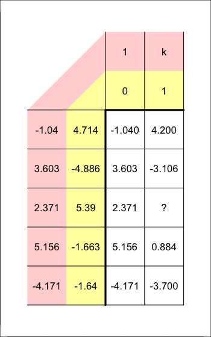

   What is the new y coordinate when point $(2.371, 5.39)$ undergoes the vertical shear transformation with $k=0.494$?

#### Question

2. A video-game developer is hoping to apply a vertical [shear](https://en.wikipedia.org/wiki/Shear_mapping) to a set of points by using matrix multiplication.

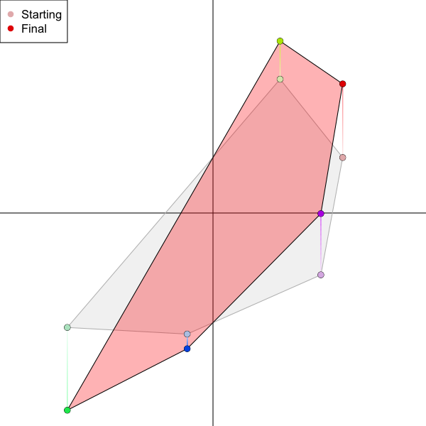

   The starting points are stored as rows in a 5 $\times$ 2 matrix $S$.

   $$S=\begin{bmatrix}
   5.246 & 2.244\\
   2.714 & 5.413\\
   -5.894 & -4.63\\
   -1.045 & -4.897\\
   4.363 & -2.502
   \end{bmatrix}$$

   The vertical shear matrix can be found by using $k=0.568$ in the formula matrix.

   $$T~=~\begin{bmatrix}
   1 & k\\
   0 & 1
   \end{bmatrix}$$

   The final points (in matrix $F$) are found by multiplying $S\cdot T$.

   $$F=S\cdot T$$

   That multiplication can be done using the diagram below.

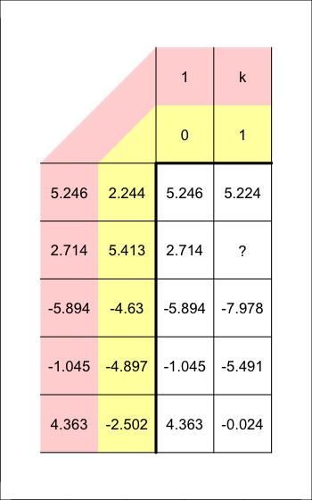

   What is the new y coordinate when point $(2.714, 5.413)$ undergoes the vertical shear transformation with $k=0.568$?

#### Question

3. A video-game developer is hoping to apply a horizontal [shear](https://en.wikipedia.org/wiki/Shear_mapping) to a set of points by using matrix multiplication.

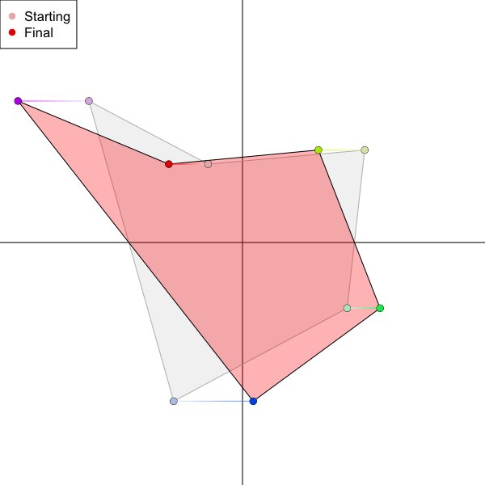

   The starting points are stored as rows in a 5 $\times$ 2 matrix $S$.

   $$S=\begin{bmatrix}
   -1.065 & 2.423\\
   3.779 & 2.86\\
   3.235 & -2.031\\
   -2.128 & -4.908\\
   -4.75 & 4.375
   \end{bmatrix}$$

   The horizontal shear matrix can be found by using $k=-0.501$ in the formula matrix.

   $$T~=~\begin{bmatrix}
   1 & 0\\
   k & 1
   \end{bmatrix}$$

   The final points (in matrix $F$) are found by multiplying $S\cdot T$.

   $$F=S\cdot T$$

   That multiplication can be done using the diagram below.

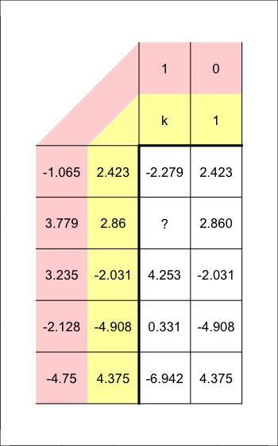

   What is the new x coordinate when point $(3.779, 2.86)$ undergoes the horizontal shear transformation with $k=-0.501$?

#### Question

4. A video-game developer is hoping to apply a vertical [shear](https://en.wikipedia.org/wiki/Shear_mapping) to a set of points by using matrix multiplication.

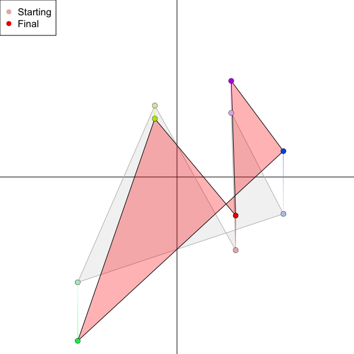

   The starting points are stored as rows in a 5 $\times$ 2 matrix $S$.

   $$S=\begin{bmatrix}
   2.997 & -3.737\\
   -1.132 & 3.648\\
   -5.07 & -5.38\\
   5.435 & -1.884\\
   2.771 & 3.274
   \end{bmatrix}$$

   The vertical shear matrix can be found by using $k=0.59$ in the formula matrix.

   $$T~=~\begin{bmatrix}
   1 & k\\
   0 & 1
   \end{bmatrix}$$

   The final points (in matrix $F$) are found by multiplying $S\cdot T$.

   $$F=S\cdot T$$

   That multiplication can be done using the diagram below.

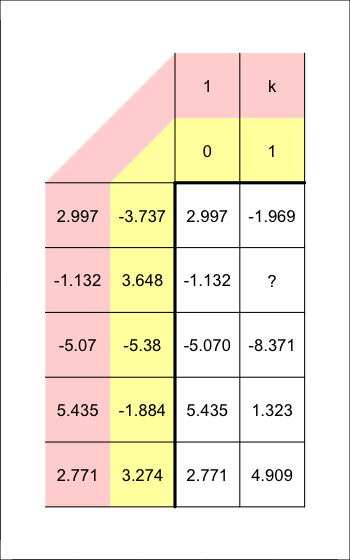

   What is the new y coordinate when point $(-1.132, 3.648)$ undergoes the vertical shear transformation with $k=0.59$?

#### Question

5. A video-game developer is hoping to apply a vertical [shear](https://en.wikipedia.org/wiki/Shear_mapping) to a set of points by using matrix multiplication.

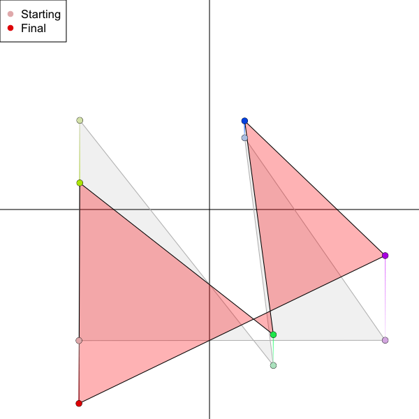

   The starting points are stored as rows in a 5 $\times$ 2 matrix $S$.

   $$S=\begin{bmatrix}
   -4.08 & -4.096\\
   -4.054 & 2.786\\
   1.996 & -4.874\\
   1.099 & 2.24\\
   5.491 & -4.087
   \end{bmatrix}$$

   The vertical shear matrix can be found by using $k=0.482$ in the formula matrix.

   $$T~=~\begin{bmatrix}
   1 & k\\
   0 & 1
   \end{bmatrix}$$

   The final points (in matrix $F$) are found by multiplying $S\cdot T$.

   $$F=S\cdot T$$

   That multiplication can be done using the diagram below.

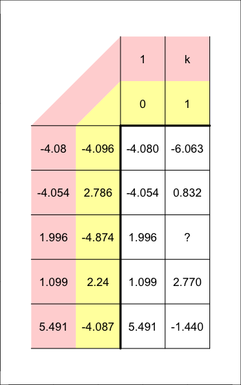

   What is the new y coordinate when point $(1.996, -4.874)$ undergoes the vertical shear transformation with $k=0.482$?

#### Question

6. A video-game developer is hoping to apply a horizontal [shear](https://en.wikipedia.org/wiki/Shear_mapping) to a set of points by using matrix multiplication.

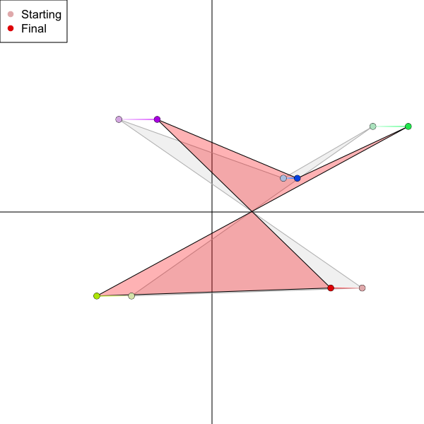

   The starting points are stored as rows in a 5 $\times$ 2 matrix $S$.

   $$S=\begin{bmatrix}
   5.541 & -2.804\\
   -2.969 & -3.097\\
   5.933 & 3.157\\
   2.632 & 1.244\\
   -3.435 & 3.415
   \end{bmatrix}$$

   The horizontal shear matrix can be found by using $k=0.414$ in the formula matrix.

   $$T~=~\begin{bmatrix}
   1 & 0\\
   k & 1
   \end{bmatrix}$$

   The final points (in matrix $F$) are found by multiplying $S\cdot T$.

   $$F=S\cdot T$$

   That multiplication can be done using the diagram below.

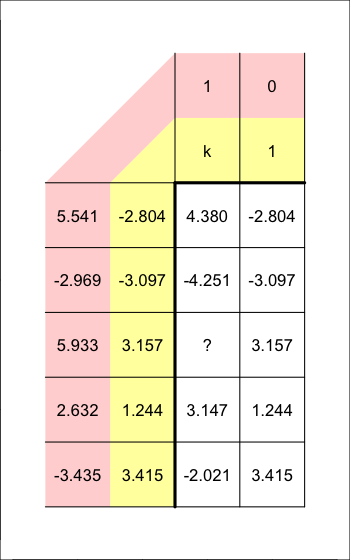

   What is the new x coordinate when point $(5.933, 3.157)$ undergoes the horizontal shear transformation with $k=0.414$?

#### Question

7. A video-game developer is hoping to apply a vertical [shear](https://en.wikipedia.org/wiki/Shear_mapping) to a set of points by using matrix multiplication.

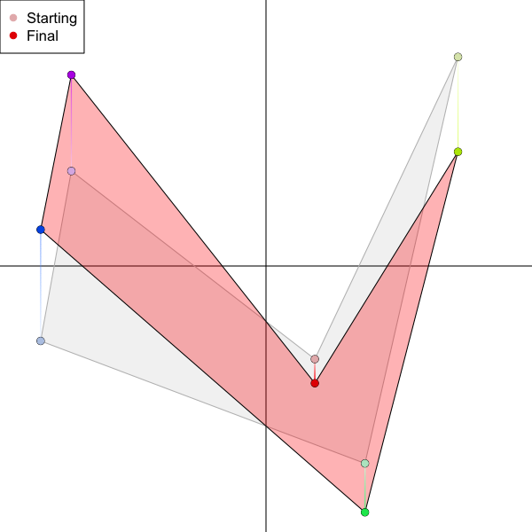

   The starting points are stored as rows in a 5 $\times$ 2 matrix $S$.

   $$S=\begin{bmatrix}
   1.275 & -2.431\\
   5.013 & 5.459\\
   2.584 & -5.154\\
   -5.884 & -1.957\\
   -5.082 & 2.48
   \end{bmatrix}$$

   The vertical shear matrix can be found by using $k=-0.494$ in the formula matrix.

   $$T~=~\begin{bmatrix}
   1 & k\\
   0 & 1
   \end{bmatrix}$$

   The final points (in matrix $F$) are found by multiplying $S\cdot T$.

   $$F=S\cdot T$$

   That multiplication can be done using the diagram below.

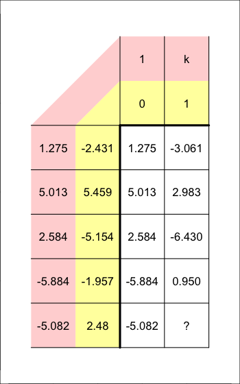

   What is the new y coordinate when point $(-5.082, 2.48)$ undergoes the vertical shear transformation with $k=-0.494$?

#### Question

8. A video-game developer is hoping to apply a horizontal [shear](https://en.wikipedia.org/wiki/Shear_mapping) to a set of points by using matrix multiplication.

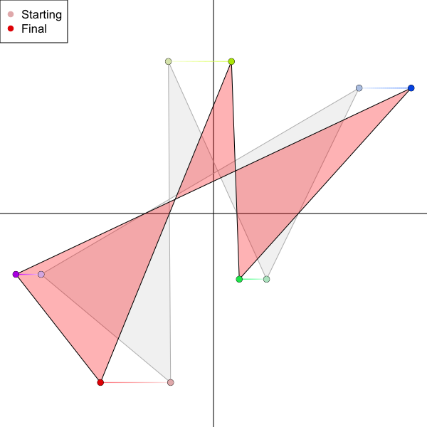

   The starting points are stored as rows in a 5 $\times$ 2 matrix $S$.

   $$S=\begin{bmatrix}
   -1.347 & -5.306\\
   -1.417 & 4.773\\
   1.666 & -2.064\\
   4.572 & 3.939\\
   -5.412 & -1.911
   \end{bmatrix}$$

   The horizontal shear matrix can be found by using $k=0.415$ in the formula matrix.

   $$T~=~\begin{bmatrix}
   1 & 0\\
   k & 1
   \end{bmatrix}$$

   The final points (in matrix $F$) are found by multiplying $S\cdot T$.

   $$F=S\cdot T$$

   That multiplication can be done using the diagram below.

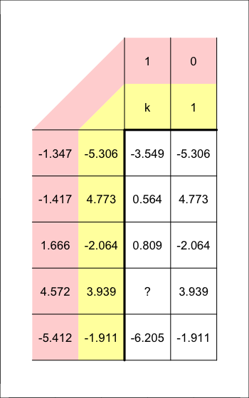

   What is the new x coordinate when point $(4.572, 3.939)$ undergoes the horizontal shear transformation with $k=0.415$?